# Project: Investigate a Dataset - [no_show_appointments]

- Introduction
- Data Wrangling
- Exploratory Data Analysis
- Conclusions

## Introduction

### Dataset Description

This dataset collects information from 100k medical appointments in Brazil and is focused on the question of whether or not patients show up for their appointment. A number of characteristics about the patient are included in each row.

PatientId Unique Number for the Patient AppointmentID Unique Number for the Appointment Gender indicates the patient gender ScheduledDay tells us on what day the patient set up their appointment. AppointmentDay tells us what is appointment date Age indicates the patient age Neighbourhood indicates the location of the hospital. Scholarship indicates whether or not the patient is enrolled in Brasilian welfare program Bolsa Família. Hipertension indicates whether or not the patient is Hipertension Diabetes indicates whether or not the patient is Diabetes Alcoholism indicates whether or not the patient is Alcoholism Handcap indicates whether or not the patient is Handcap  
SMS_received indicates whether or not the patient sent SMS No-show indicates whether or not the patientit showed up, it says ‘No’ if the patient showed up to their appointment, and ‘Yes’ if they did not show up.

### Question(s) for Analysis

What is the % of patients who showed up vs the none-showed up ones? Is there the patient age affects the show up rate? Is there a correlation between the patient gender and the show up rate? Is the scholarship enrolment affect his presence in the scheduled appointments?

```python
import pandas as pd
import numpy as np
import matplotlib.pyplot as plt
%matplotlib inline
```

```python
# Upgrade pandas to use dataframe.explode() function.
!pip install --upgrade pandas==0.25.0
```

## Data Wrangling

### General Properties

```python
df= pd.read_csv('noshowappointments-kagglev2-may-2016.csv')
df.head()
```

|  | PatientId | AppointmentID | Gender | ScheduledDay | AppointmentDay | Age | Neighbourhood | Scholarship | Hipertension | Diabetes | Alcoholism | Handcap | SMS_received | No-show |
| --- | --- | --- | --- | --- | --- | --- | --- | --- | --- | --- | --- | --- | --- | --- |
| 0 | 2.987250e+13 | 5642903 | F | 2016-04-29T18:38:08Z | 2016-04-29T00:00:00Z | 62 | JARDIM DA PENHA | 0 | 1 | 0 | 0 | 0 | 0 | No |
| 1 | 5.589978e+14 | 5642503 | M | 2016-04-29T16:08:27Z | 2016-04-29T00:00:00Z | 56 | JARDIM DA PENHA | 0 | 0 | 0 | 0 | 0 | 0 | No |
| 2 | 4.262962e+12 | 5642549 | F | 2016-04-29T16:19:04Z | 2016-04-29T00:00:00Z | 62 | MATA DA PRAIA | 0 | 0 | 0 | 0 | 0 | 0 | No |
| 3 | 8.679512e+11 | 5642828 | F | 2016-04-29T17:29:31Z | 2016-04-29T00:00:00Z | 8 | PONTAL DE CAMBURI | 0 | 0 | 0 | 0 | 0 | 0 | No |
| 4 | 8.841186e+12 | 5642494 | F | 2016-04-29T16:07:23Z | 2016-04-29T00:00:00Z | 56 | JARDIM DA PENHA | 0 | 1 | 1 | 0 | 0 | 0 | No |

```python
df.shape
```

```
(110527, 14)
```

```python
df.describe()
```

|  | PatientId | AppointmentID | Age | Scholarship | Hipertension | Diabetes | Alcoholism | Handcap | SMS_received |
| --- | --- | --- | --- | --- | --- | --- | --- | --- | --- |
| count | 1.105270e+05 | 1.105270e+05 | 110527.000000 | 110527.000000 | 110527.000000 | 110527.000000 | 110527.000000 | 110527.000000 | 110527.000000 |
| mean | 1.474963e+14 | 5.675305e+06 | 37.088874 | 0.098266 | 0.197246 | 0.071865 | 0.030400 | 0.022248 | 0.321026 |
| std | 2.560949e+14 | 7.129575e+04 | 23.110205 | 0.297675 | 0.397921 | 0.258265 | 0.171686 | 0.161543 | 0.466873 |
| min | 3.921784e+04 | 5.030230e+06 | -1.000000 | 0.000000 | 0.000000 | 0.000000 | 0.000000 | 0.000000 | 0.000000 |
| 25% | 4.172614e+12 | 5.640286e+06 | 18.000000 | 0.000000 | 0.000000 | 0.000000 | 0.000000 | 0.000000 | 0.000000 |
| 50% | 3.173184e+13 | 5.680573e+06 | 37.000000 | 0.000000 | 0.000000 | 0.000000 | 0.000000 | 0.000000 | 0.000000 |
| 75% | 9.439172e+13 | 5.725524e+06 | 55.000000 | 0.000000 | 0.000000 | 0.000000 | 0.000000 | 0.000000 | 1.000000 |
| max | 9.999816e+14 | 5.790484e+06 | 115.000000 | 1.000000 | 1.000000 | 1.000000 | 1.000000 | 4.000000 | 1.000000 |

```python
df.info()
```

```
<class 'pandas.core.frame.DataFrame'>
RangeIndex: 110527 entries, 0 to 110526
Data columns (total 14 columns):
PatientId         110527 non-null float64
AppointmentID     110527 non-null int64
Gender            110527 non-null object
ScheduledDay      110527 non-null object
AppointmentDay    110527 non-null object
Age               110527 non-null int64
Neighbourhood     110527 non-null object
Scholarship       110527 non-null int64
Hipertension      110527 non-null int64
Diabetes          110527 non-null int64
Alcoholism        110527 non-null int64
Handcap           110527 non-null int64
SMS_received      110527 non-null int64
No-show           110527 non-null object
dtypes: float64(1), int64(8), object(5)
memory usage: 11.8+ MB
```

### Data Cleaning

```python
# no null data to be dropped
# need to delete the invalid data (age <=0)
df.drop(df.loc[df['Age']<=0].index, inplace=True)
```

```python
#chcek
df.describe()
```

|  | PatientId | AppointmentID | Age | Scholarship | Hipertension | Diabetes | Alcoholism | Handcap | SMS_received |
| --- | --- | --- | --- | --- | --- | --- | --- | --- | --- |
| count | 1.069870e+05 | 1.069870e+05 | 106987.000000 | 106987.000000 | 106987.000000 | 106987.000000 | 106987.000000 | 106987.000000 | 106987.000000 |
| mean | 1.472814e+14 | 5.675434e+06 | 38.316085 | 0.101031 | 0.203772 | 0.074243 | 0.031406 | 0.022975 | 0.323264 |
| std | 2.558267e+14 | 7.133274e+04 | 22.466214 | 0.301371 | 0.402804 | 0.262167 | 0.174412 | 0.164115 | 0.467725 |
| min | 3.921784e+04 | 5.030230e+06 | 1.000000 | 0.000000 | 0.000000 | 0.000000 | 0.000000 | 0.000000 | 0.000000 |
| 25% | 4.173523e+12 | 5.640490e+06 | 19.000000 | 0.000000 | 0.000000 | 0.000000 | 0.000000 | 0.000000 | 0.000000 |
| 50% | 3.172463e+13 | 5.680744e+06 | 38.000000 | 0.000000 | 0.000000 | 0.000000 | 0.000000 | 0.000000 | 0.000000 |
| 75% | 9.433600e+13 | 5.725634e+06 | 56.000000 | 0.000000 | 0.000000 | 0.000000 | 0.000000 | 0.000000 | 1.000000 |
| max | 9.999816e+14 | 5.790484e+06 | 115.000000 | 1.000000 | 1.000000 | 1.000000 | 1.000000 | 4.000000 | 1.000000 |

```python
# check for duplicates
duplicates = df.duplicated()
duplicates.sum()
```

```
0
```

```python
# drop cloumns that won't need in my analysis
df.drop(['AppointmentID','PatientId','ScheduledDay','AppointmentDay'],axis=1,inplace=True)
```

```python
#check
df.info()
```

```
<class 'pandas.core.frame.DataFrame'>
Int64Index: 106987 entries, 0 to 110526
Data columns (total 10 columns):
Gender           106987 non-null object
Age              106987 non-null int64
Neighbourhood    106987 non-null object
Scholarship      106987 non-null int64
Hipertension     106987 non-null int64
Diabetes         106987 non-null int64
Alcoholism       106987 non-null int64
Handcap          106987 non-null int64
SMS_received     106987 non-null int64
No-show          106987 non-null object
dtypes: int64(7), object(3)
memory usage: 9.0+ MB
```

```python
#convert headres names to lower case
df.columns= df.columns.str.lower()
#check
df.columns
```

```
Index(['gender', 'age', 'neighbourhood', 'scholarship', 'hipertension',
       'diabetes', 'alcoholism', 'handcap', 'sms_received', 'no-show'],
      dtype='object')
```

```python
# change no-show to no_show
df.rename(columns={'no-show':'no_show'},inplace=True)
#check
df.columns
```

```
Index(['gender', 'age', 'neighbourhood', 'scholarship', 'hipertension',
       'diabetes', 'alcoholism', 'handcap', 'sms_received', 'no_show'],
      dtype='object')
```

### Have a look on the data

```
array([[<matplotlib.axes._subplots.AxesSubplot object at 0x7f440c7246d8>,
      dtype=object)
```

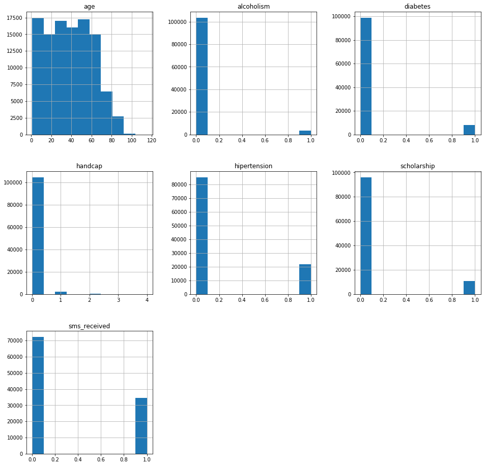

```python
df.hist(figsize=(16,16))
```

# Most of patients are not alcoholic, hand capped, diabetes, hypertension, not enrolled in scholarship and didn't send sms

# Research Question 1: What is the % of patients who showed up vs the none-showed up ones?

```python
show=df['no_show']=='No'
not_show=df['no_show']=='Yes'
n_sh=df[show]['age'].count()
n_not_sh=df[not_show]['age'].count()
total=df.shape[0]
```

```python
print (n_sh,n_not_sh )
```

```
85307 21680
```

```python
print('percentage of patients who show up',((n_sh/total)*100).round(),'%')
print('percentage of patients who do not show p',((n_not_sh/total)*100).round(),'%')
```

```
percentage of patients who show up 80.0 %
percentage of patients who do not show p 20.0 %
```

# Research Question 2: Is the patient age affects the show up rate?

```python
kids = df['age'] <= 20
kids_counts= df[kids][not_show]['gender'].count()
kids_counts
```

```
6457
```

```python
mid_age= df['age'] <=60
mid_age_counts= df[mid_age][not_show]['gender'].count() - kids_counts
mid_age_counts
```

```
12217
```

```python
old_age= df['age'] > 60
old_age_counts= df[old_age][not_show]['gender'].count()
old_age_counts
```

```
3006
```

```python
total= kids_counts + mid_age_counts + old_age_counts
total
```

```
21680
```

```python
pkids_counts = (kids_counts/ total*100).round()
pmid_counts= (mid_age_counts/ total*100).round()
pold_counts= (old_age_counts/ total*100).round()
print(pkids_counts, '%',pmid_counts, '%', pold_counts, '%')
```

```
30.0 % 56.0 % 14.0 %
```

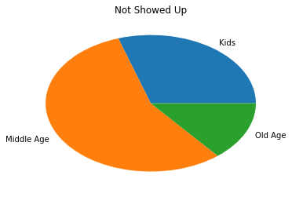

```python
age_showup_rate= np.array([pkids_counts, pmid_counts, pold_counts])
pie_labels= ["Kids","Middle Age", "Old Age"]
plt.pie(age_showup_rate, labels = pie_labels)
plt.title('Not Showed Up')
plt.show()
```

### Research Question 3: Is there a correlation between the patient gender and the show up rate?

```python
gender_counts = df.groupby(['gender', 'no_show']).count()['age']
gender_counts
```

```
gender  no_show
F       No         55843
        Yes        14275
M       No         29464
        Yes         7405
Name: age, dtype: int64
```

```python
gender_totals = df.groupby('gender').count()['age']
gender_totals
```

```
gender
F    70118
M    36869
Name: age, dtype: int64
```

```python
pfemale = (gender_counts['F'] / gender_totals['F'] *100).round()
pmale = (gender_counts['M'] / gender_totals['M']*100).round()

print (pfemale, pmale)
```

```
no_show
No     80.0
Yes    20.0
Name: age, dtype: float64 no_show
No     80.0
Yes    20.0
Name: age, dtype: float64
```

[figure not shown]

```python
height = np.array([20,80]).any()  # the bar height for the groups
width = .50       # the width of the bars

# plot bars
female_bars = plt.bar(ind, pfemale, width, alpha = .5, color='r',  label='female')
male_bars = plt.bar(ind+width, pmale, width, alpha = .5 , color='b',  label='male')
plt.ylabel('Gender Percentage')
plt.xlabel('show')
plt.title('Gender/Showup Rate')
locations = height , width  # xtick locations
labels = ['show', 'No Show']  # xtick labels
plt.xticks(locations, labels)
plt.legend()
```

### No Correlation between Gender and Show up Rate

### Research Question 4: Is the scholarship enrolment affect the patient presence in the scheduled appointments?

```python
df['scholarship'] = df['scholarship'].astype(str)
scolarship_counts = df.groupby(['scholarship', 'no_show']).count()['age']
scolarship_counts
```

```
scholarship  no_show
0            No         77069
             Yes        19109
1            No          8238
             Yes         2571
Name: age, dtype: int64
```

```python
scholarship_totals = df.groupby('scholarship').count()['age']
scholarship_totals
```

```
scholarship
0    96178
1    10809
Name: age, dtype: int64
```

```python
pwelfare = (scolarship_counts['0'] / scholarship_totals['0']*100).round()
pno_welfare = (scolarship_counts['1'] / scholarship_totals['1']*100).round()
print (pwelfare,pno_welfare)
```

```
no_show
No     80.0
Yes    20.0
Name: age, dtype: float64 no_show
No     76.0
Yes    24.0
Name: age, dtype: float64
```

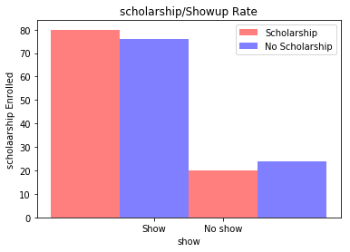

```python
height = np.array([80,20]).any()  # the bar height for the groups
width = .5       # the width of the bars

# plot bars
Welfare_bars = plt.bar(ind, pwelfare, width, color='r', alpha=.5, label='Scholarship')
No_welfare_bars = plt.bar(ind + width, pno_welfare, width, color='b', alpha=.5, label='No Scholarship')
plt.ylabel('scholaarship Enrolled')
plt.xlabel('show')
plt.title('scholarship/Showup Rate')
locations = height , width   # xtick locations
labels = ['No show', 'Show']  # xtick labels
plt.xticks(locations, labels)
plt.legend()
```

## Conclusions

After Loading the data and explore it i have done some cleaning procedures which are:

- checking for null values - Result : none
- checking for duplicates - Result: none
- Age column had and invalid values so i had to drop it.
- Columns headers were in capital and lower case letters, i made them all lowe case.
- no- show column header had a dash instead of underscore, and it is a highly used one so i replaced the dash with undescore;
- There were some other cloumns that won't be used, so i dropped them all.

I started exploring data stage with ploting (created histograms) to all the columns to have an overall idea about the data then I started to work on each of my analysis questions which were:

1- What is the % of patients who show up vs the none show up ones? 2- Is the patient age affects show up rate? 3- What is the correlation between the patient gender and the show up rate? 4- Does the patientenrolment in scholarship affect his presence in the scheduled appointments?

Below were all the results concluded from analyzing the data:

• Most of patients are not alcoholic, hand capped, diabetes, hypertension, not enrolled in scholarship and didn't send sms.

• percentage of patients who show up 80.0 % • percentage of patients who do not show p 20.0 %

• No Correlation between Gender and Show up Rate

## Submitting your Project

```python
from subprocess import call
call(['python', '-m', 'nbconvert', 'Investigate_a_Dataset.ipynb'])
```

```
0
```